# Intro to Embedded Device Exploitation: Shellcode 0

or everything is broken and nothing is safe

# Preface and Background Knowledge

## Goal

Welcome! In this challenge we will cover the basics of exploitation writing. Our target is an OpenWRT router with a vulnerable HTTP server. The **goal** is to write a Proof of Concept (**POC**) for Remote Code Execution (**RCE**). We are going to reboot it as our Proof of Concept.

This was written and tested from Kali Linux and Ubuntu

Next we will loosely cover some of the knoweldge base that will help to set the foundation of what we are doing

## Embedded Systems

What are embedded systems?

"An embedded system is a micro-processor based computer hardware system with software that is designed to perform a dedicated function, either as an indpendent system or as a part of a larger system."

Embedded systems include routers, smartphones, car computers, smart watches, pretty much anything labeled "smart", and industrial systems.

They usually run a small linux or customer operating system

## Programming Languages

There are a lot of programming languages out there. Usually we work in higher level langauges and scripting languages, but today we will take a look at some of the lower stuff.

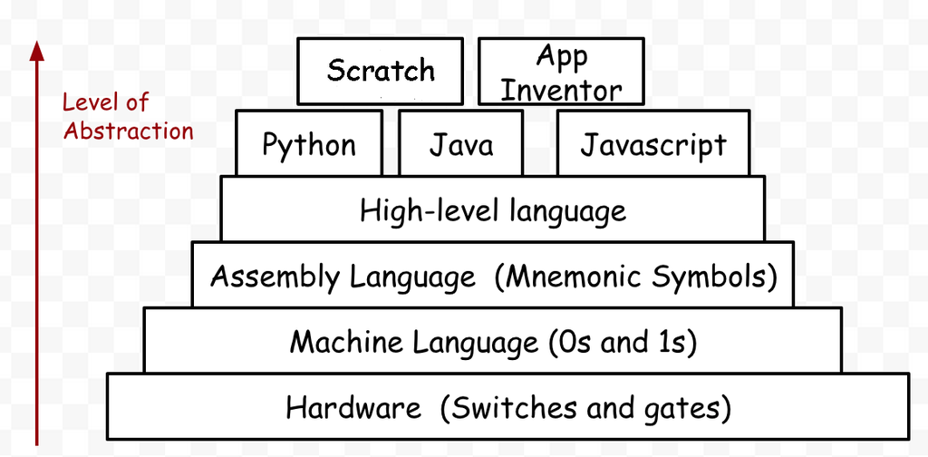

We usually work with the higher languages because they are easier to develop with but they run slower, in part due to the overhead of added feautures in the background such as garbage collection.

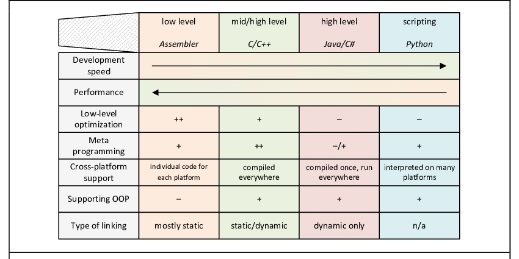

**Runtime speed examples**

From https://programming-language-benchmarks.vercel.app: a comparison of runtimes with 2.5 million input

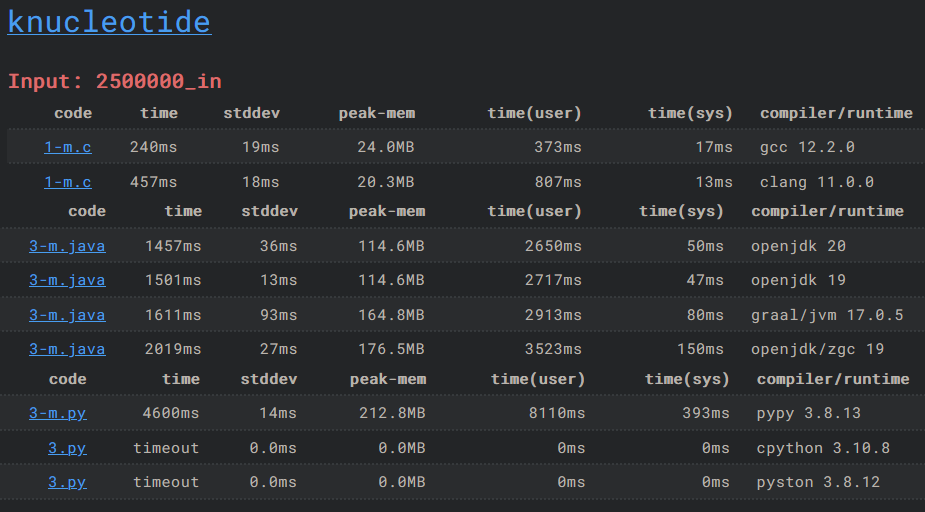

You can see the performance difference between the C, Java, and Python. 2 of the Pythons exceeded 5 seconds and timed out. For small applications python is fine but when dealing with millions of inputs other languages may be better

## Memory

We aren't going to go too into the weeds but here is a brief overview of a computer's memory layout so we can understand how the CPU works

For an individual process, the memory map looks roughly like this. The Kernel is the Operating System and in that memory the kernel loads the syscalls, maps input and output, as well as all the other necessities to run the system.

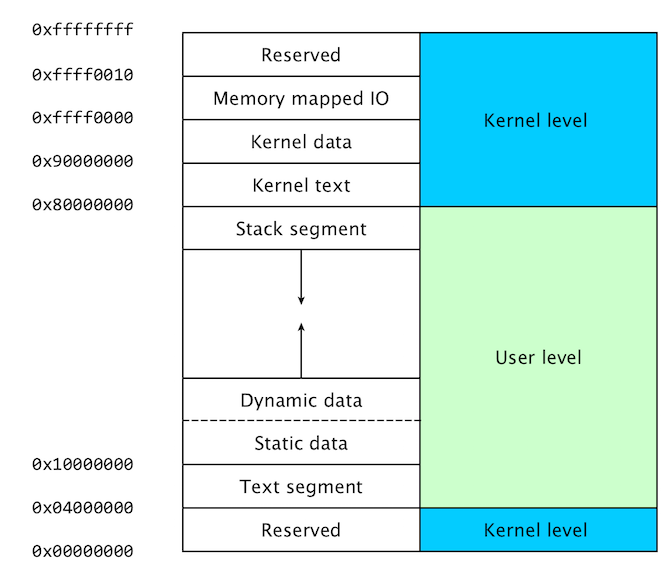

This visual representation is commonly used to show how data is arranged and make it easier to think about. Below is an image from ghidra (more on that later) for now we only care about the first two columns.  
The **address of the data** in the system is in first column and the **data** is in the second column (4 groups of 2 characters), the rest is the data translated to mips assembly

These are the same for the image above. The addresses in a 32 bit system range from `0x00000000` to `0xffffffff`. Usually program's code start at `0x04000000`, the text segment in the user level with variables and data above it.

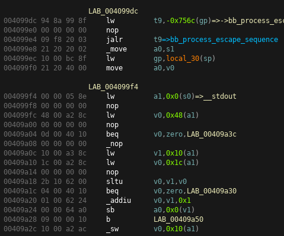

The numbers are displayed in Hexadecimal to be easier for humans to read but in reality the cpu sees 0's and 1's. Hexadecimal is easily identiable due to the letters and is often led with 0x

**Click here for Hexadecimal refresher**

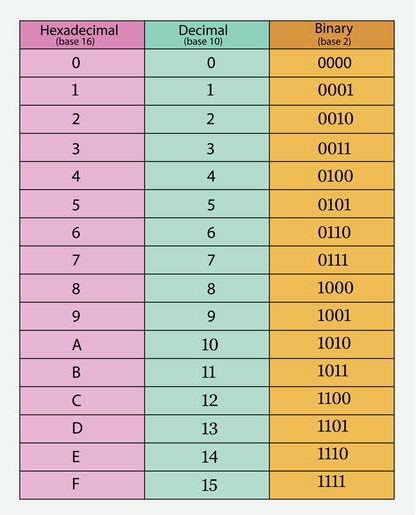

```
We usually think in base 10 or Decimal. In programming we frequently use base 16 or Hexadecimal. Basically we can use 0-9 as a digit and at 10 we add a 10s place. With Hexadecimal we use 0-F to range 0-15 then 10 equals 16.
We do this because computers use binary (base 2) with 1 representing on and 0 representing off. Using hexadecimal is a much faster and easier way for us to read the values from binary.
```

## Virtual Memory and Paging

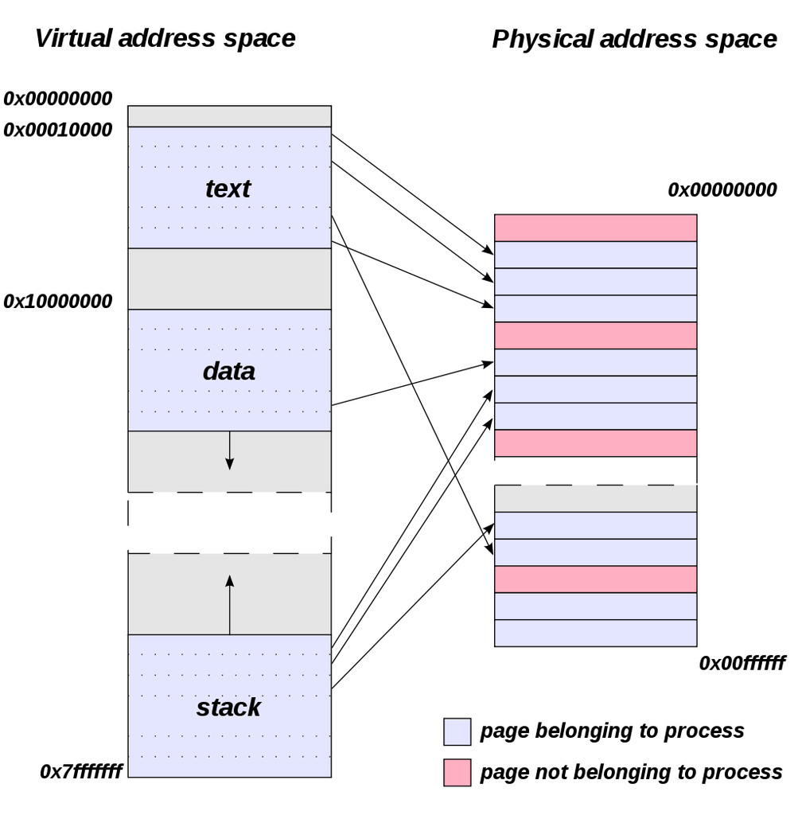

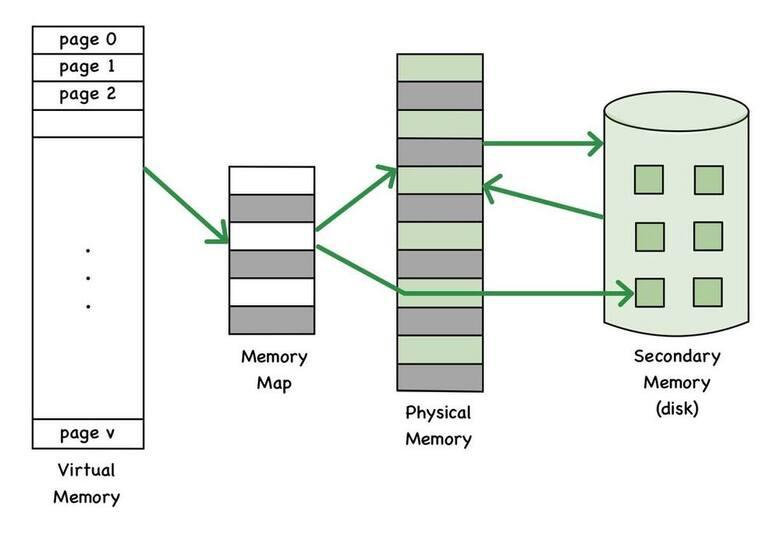

Accessing data on the hard drive is slower than that in ram

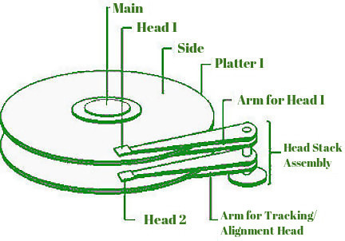

## Network stack

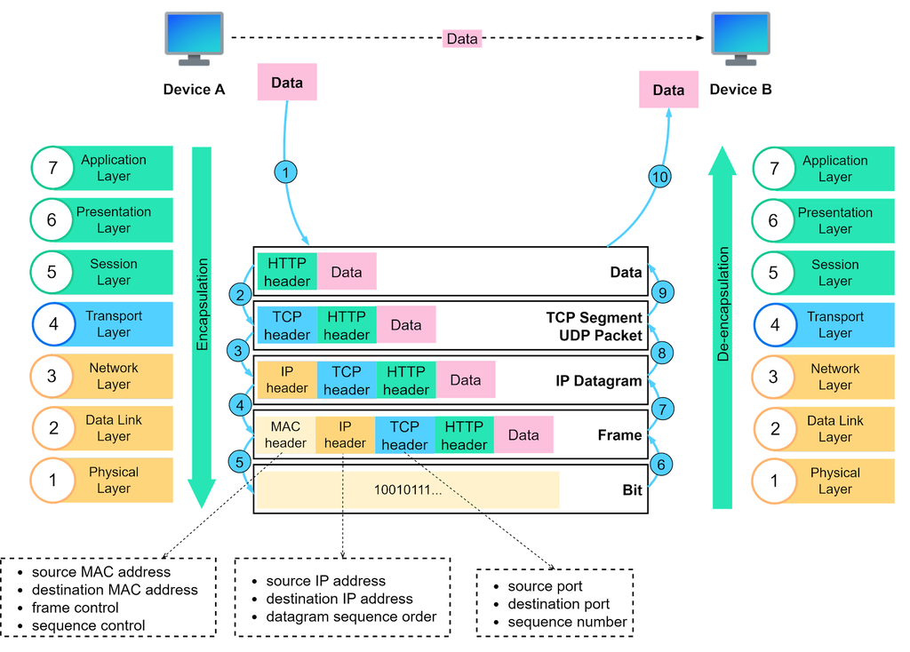

## MIPS Assembly Language and the CPU

Our target is going to be using 32 bit MIPS architecture

**MIPS** is cheap and low power, so it is prevalent in IOT devices.  
**ARM** is powerful and efficient, used in AMD chips, rasberry PI, Andriod, and new Macs.  
**PowerPC** is common in commercial-grade hardware, Cisco, and game consoles such as Xbox and Playstation.  
**x86** is Intel's design and usually is more powerful than ARM but also much more power hungry.

Here is a diagram of a MIPS processor, PC is the program counter and contains the current address of the code being executed.  
Take a look at the Instruction memory block, PC provides the address and we get the instruction stored at that address. Just like the first two columns in the previous pictures.

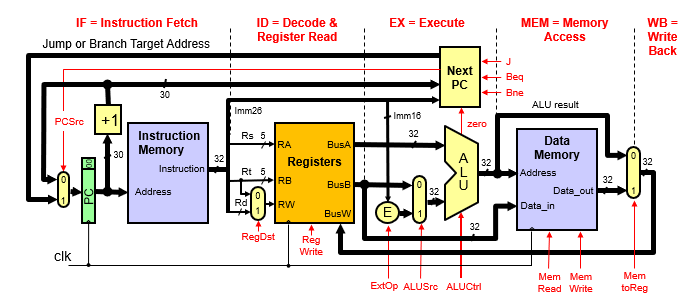

The second step is decoding the instruction. Followed by executing that instruction, then writing back to the disk or register file

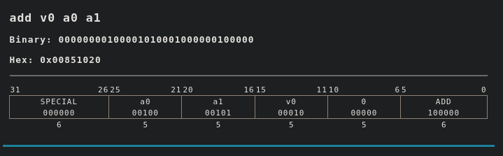

### Pipelining

Most architectures use a version of **pipelining** and/or speculative execution methods to improve performance.

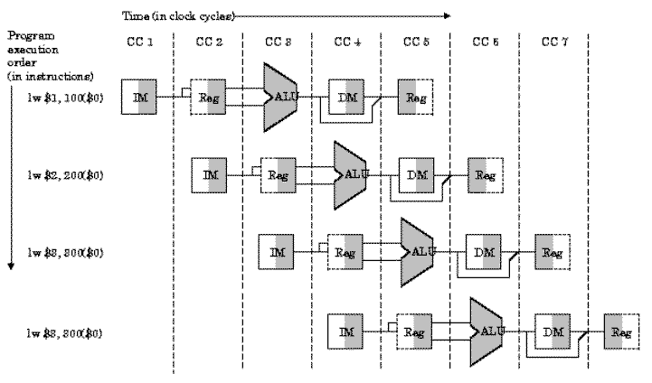

### Delay Slot

It takes more than 1 computer clock cycle to complete an instruction, this cpu uses 5 steps for each instruction.  
This means by the time the CPU knows an instruction is a jump, it has already loaded and will execute the next instruction. This creates a **Delay Slot**, the instruction after a jump. It will always execute, regardless of whether it takes the jump or not.

*This is specific to RISC architectures*

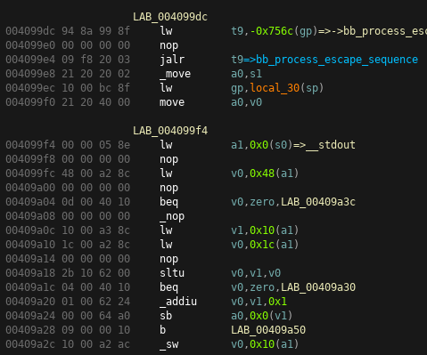

Looking back at this snippet again we can see the delay slots. Every instruction starting with a j is a jump, and b is a branch. Jumps are unconditional while branches are tied to a conditional statement. A useful top is that in Ghidra these delay slots are identified with an underscore before the instruction.

### RISC

MIPS uses a **Reduced Instruction Set Computer (RISC)** which means each instruction is fixed length, every action is 4 bytes (each byte is 8 bits, for 32 bits total). RISC instruction sets use simpler instructions and need fewer stages in their pipeline to complete their execution.  
Meanwhile a **Complex Instruction Set Computer (CISC)** *(ex x86)* has more complex and variable length instructions. The instructions in a CISC architecture take more steps to execute but also allow for a smaller code base as one CISC instruction might do the same as several instructions in a RISC architecture.

### Registers

MIPS uses load/store to move values between memory and registers and then acts on them in registers. Registers are kinda like the CPU's fingers for quick use/math. Registers are less expensive and quicker to use than to write data back to memory.  
The registers we will care the most about are the **arguments** (**a0-a3**), **return values** (**v0-v1**), the **stack pointer** (**sp**), and the **return address** (**ra** but also called the **link register**)

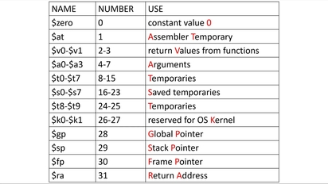

### Instruction Types

MIPS has 3 main types of instructions **R - Register**, **I - Immediate**, and **J - Jump**.

**R** - have the operation, a destination register, and can have two source registers. For example:

```
add v0, a0, a1    # adds register a0 with a1
                  # then saves the result to v0
```

**I** - raw values are called immediates and when they are used a different format is needed. For example:

```
addiu v0, v1, 0x01    # adds unsigned immediate value 01
                      # to v1 and saves in v0
```

**J** - changes the flow of execution, jumps and conditional jumps called branches. The target can be a register or address. For example:

```
jalr t9   # Jump to value in t9, And Link
          # Register (save return address)
```

Each type of instruction has a slightly different layout

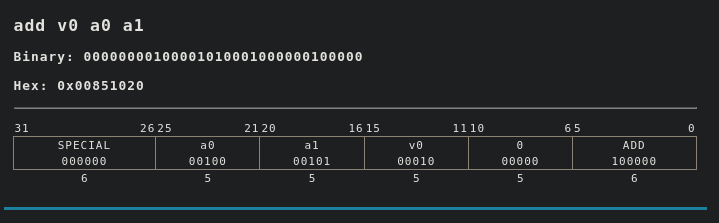

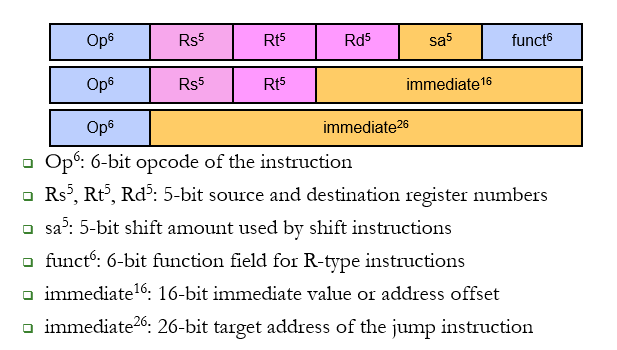

### Shellcode

Now we have a basic understanding of the CPU and the code it is executing. Our goal is to find a bug, use it to hijack the flow of execution, and have it execute our code.

Our code will be in the form of **shellcode** and will be hand crafted assembly like above to make it do what we want it to do.

Per wikipedia "It is called "**shellcode**" because it typically starts a command shell from which the attacker can control the compromised machine, but any piece of code that performs a similar task can be called shellcode."

# Setting up the Environment

For this exercise we are using **qemu** to **emulate an OpenWRT router** as a target with a vulnerable http server running.

You should have received either a Kali Linux ISO with all the tools or a folder with the contents if you are running your own linux environment. If you are using your own environment, take a moment and install the following tools:

Going to need to installed:

- gdb-multiarch
- gef (on github: optional gdb plugin for a nicer appearance and improved functionality)
- qemu-system-mips
- doona / bed fuzzers (which ever is in your repo)
- python3
- ghidra
- wireshark

## Networking

If you are not using one of our physical devices, enter the following in a terminal to setup the networking:

```
sudo ip tuntap add dev tap0 mode tap user `whoami`;
sudo ip addr add 192.168.100.100/24 dev tap0;
sudo ip link set tap0 up
```

## Emulation

Find the shellcode 0 folder, open a terminal there and use the following to launch the emulation:

```
qemu-system-mips -M malta -drive file=./root.ext4 -kernel \
./openwrt-malta-be-vmlinux.elf -nographic -append "root=/dev/sda console=ttyS0" \
-netdev tap,id=lan,ifname=tap0,script=no,downscript=no -device pcnet,netdev=lan
```

Now you should get something like this and hit enter to see the OpenWRT Welcome Message

[figure not shown]

This is a root shell on the target for introspection. With it we can see what's happening to it as we go

# Diving in

## Investigate

Since this shell provides introspection into the target, we can take a look around. *Be careful not to change or delete things until you know what it is or you could end up bricking your target*

Google is your best friend. When working with a new target, try to learn as much as you can about it. We see it is running OpenWRT, trying googling that. OpenWRT is a open source router firmware and as such the community has a decent pool of information on various routers.

We can identify the operating system we are using with `uname -a` in the terminal for the target router

Also from the top of the welcome message above we see **"BusyBox"**, this is common for Embedded Linux systems. It is a binary with links to many of the command line calls. Often if a device does not contain the commands you want/need you can load a busybox for the architecture that contains the commands you want.

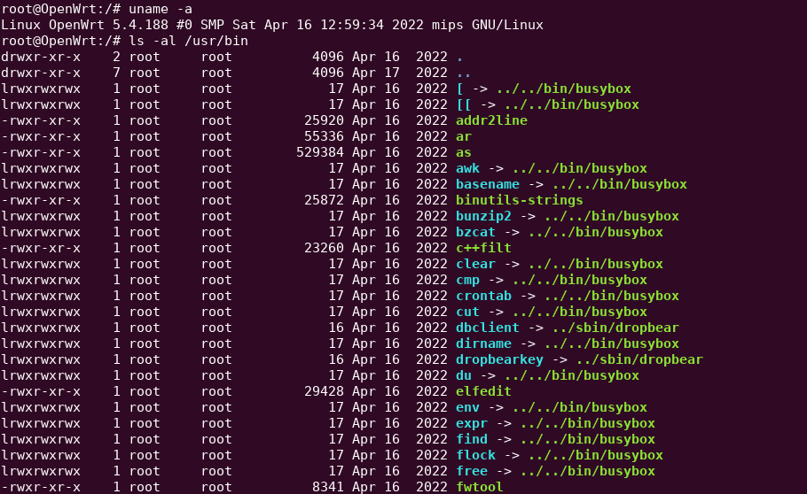

With linux you can usually find all available commands with either `?`, `help`, or hitting **tab**. In this case two tabs will list all available commands.

## Protocols

In most cases you aren't going to have someone telling you what protocol or service to look at. Usually we identify what is running or might be reasonably running in the wild and look at those.

For this exercise, we are looking at HTTP.

The `ps` command will list the currently running processes

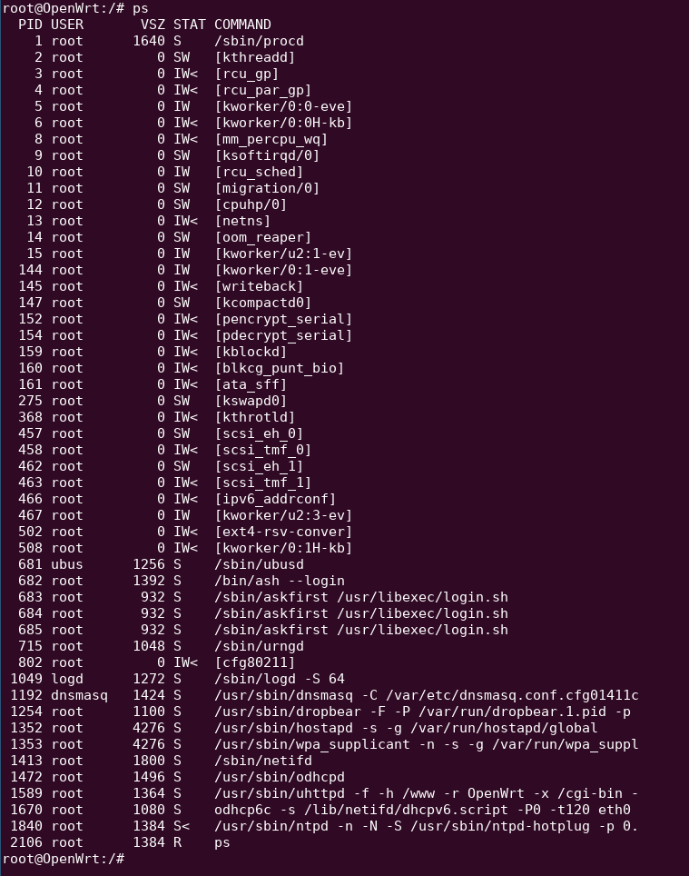

Towards the bottom we see the process ID (PID) `1589 /usr/sbin/uhttpd` - *this can change so it may not be 1589 on your system*

## Memory Map

An interesting folder to look in is `/proc/<PID>`, it will contain all kinds of information for the system about the process. This is `/proc/1589/maps`

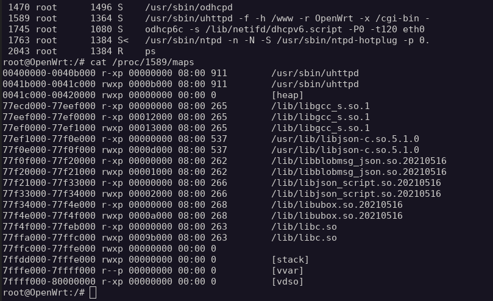

Above you can see the memory map for the process and the address ranges where different sections of code and libraries are located and their permissions.

You can cross reference the image of the memory layout from the begining. The orientation is flipped and this is just the user segment for the process.

## Pulling Binaries

It is usually easier and safer to analyze the binaries from the target on your host system.

There is usually at least one file transfer protocol already loaded onto a device, such as FTP and SCP. In this case SCP is already installed. SCP uses the following format

```
scp username@hostname:path/to/source username@hostname:path/to/destination
```

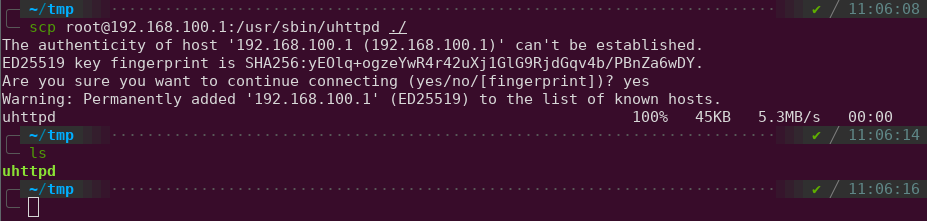

# Fuzzing

As they say **"Always be fuzzing"**

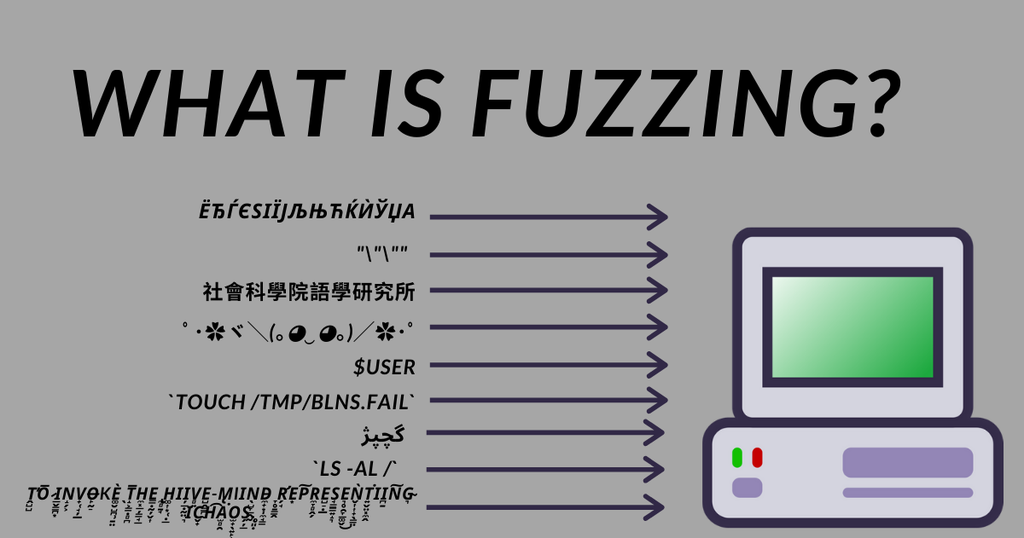

If an application asked for age and you put the above into the text field, how does it handle the unexpected input?

**Fuzzing** is providing unexpected input to get unexpected results. We use it to find bugs in systems.

Fuzzing is a huge topic, people get PhDs on the fuzzing topics like fuzzing efficiency, generating accurate code coverage, mutation strategies, and more. We are just going to touch on the basics

- **Whitebox** is with source code, can create harnesses and smart fuzzers. You can modify the source code so you get feedback on how its going, ex AFL
- **Blackbox** is without knowledge of the internals or source code, usually dumb fuzzing (without any feedback) ex Doona (what we are going to use)
- Mutation fuzzing uses a corpus of good data and changes it in interesting ways
- Generation fuzzing is creating the data from scratch, can be based on rules or a syntax

## Whitebox Fuzzer

An example of a **Whitebox** fuzzer would be Google's AFL. To use it you need the source code of the target and you modify it to create a harness. By added flags before the input is received and after the target section of code, the fuzzer can re-run just that section of code inserting the fuzzed data directly into it. This code can then be compiled with LLVM to provide feedback to the fuzzer on branches hit which gives us code coverage data, letting us know how much of the code base is being hit. Then from finding new coverage the fuzzer can make "smart" decisions on how to modify the data it throws and which seeds to save and continue mutating to increase the coverage.

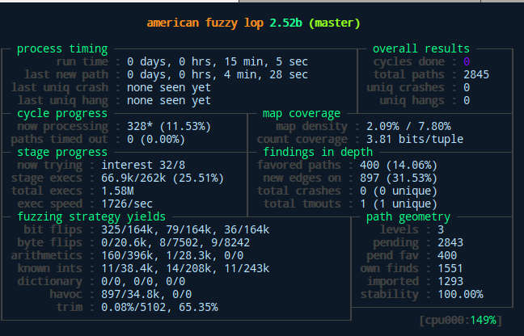

## Blackbox Fuzzer

In comparison, we are in a **Blackbox** situation. We have a target system, we can pull the compiled binary, but we do not have source code.

For each test case, we need to go through the network stack. For example, HTTP uses TCP so for each test case it will do a new TCP handshake. Additionally, to check if the system is still functioning properly you may need to do another handshake as part of your health check. Fuzzing over a network adds a lot of delay.

In the above AFL, they are getting 1726 test cases a second. How many do you think we can get?

For each test case we use, its like refreshing a web page. How many times can it reload in a second?

We can study the expected data format from RFCs or the source code and write a fuzzer to send data based on that but mutated. In a real target you can fuzz, then while its running study the binary/protocol and modify the fuzzer to hit different sections of the code base.

## Wireshark

Take a second to launch wireshark. If you haven't used it before, it is used to view packets. It should look like this, if it doesn't try `sudo wireshark` in a terminal

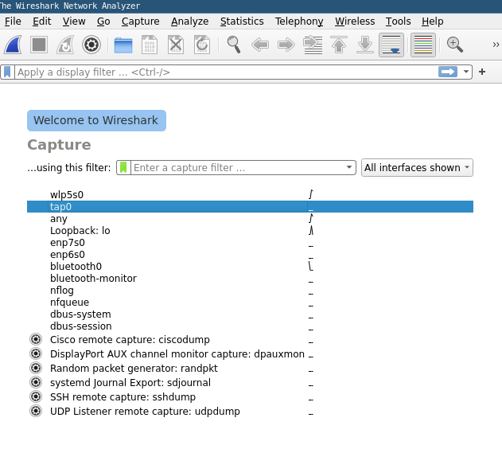

and double click on the tap0 interface in the middle

We are using wireshark so that when we get a crash, we can see exactly what was sent to cause the crash. Wireshark is not always needed

## Fuzzing the target

For this we are using the doona/bed fuzzer. Whichever you can install from your repo. These are essentially the same. It has a bunch of predefined patterns it throws to force a crash.

Use this in a terminal:  
`doona -m HTTP -t 192.168.100.1 -r 346`  
*the r is for a seed value, this will give us a prettier crash to work with*

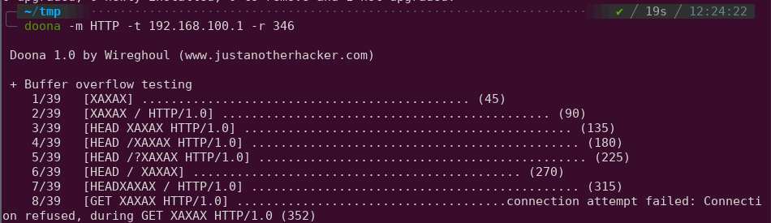

This fuzzer iterates through predefined patterns looking for vulnerabilities in the target

## Crash

WOOO! It crashed! The first thing to do when this happens, is to be able to repeat it so we know it isn't a fluke.

Remember unexpected behavior can be a crash. Crashes can manifest as hung programs, closed sockets, request rejections and more. And crashes lead to potential remote code execution.

Let's go over to wireshark and see if we can identify the packet that crashed it.

[figure not shown]

I applied a http filter at the top to hide the handshakes, and the packet that crashed it should be the last one.

## Replicating the Crash

Since we want to be able to recreate this at will, ideally with our own script and not just calling doona/bed again. Look for an `exploit_template.py` included with the shellcode0 folder or you can write your own packet thrower if you prefer.

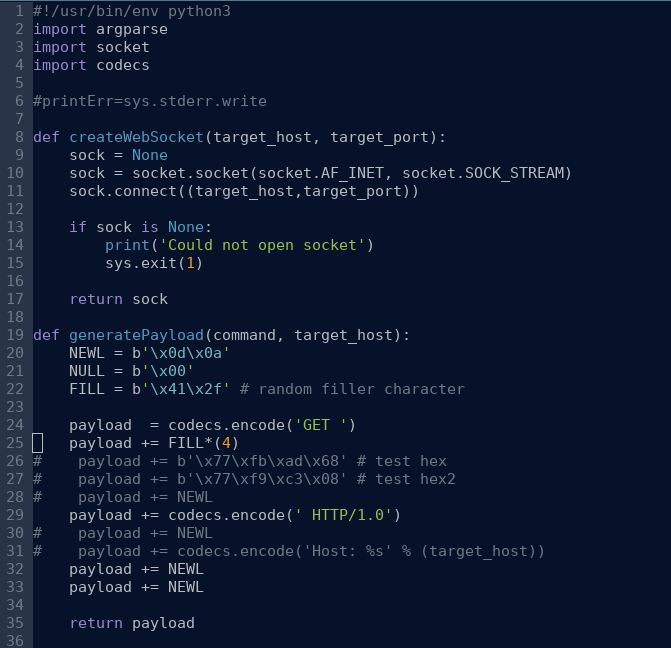

It should look something like this. The only part of the code we should need to change is the `generatePayload` function. We want the script to throw a packet like the one from wireshark

You may notice that variable `FILL` is `b'\x41\x2f'`

- the b notes for binary
- ' for string
- \ to escape the character (meaning not to print the x)

so the \x means the hex values

If we scroll up, we see that the packet in wireshark is full of `A/A/` or `x41 x2f x41 x2f`

These are the ASCII representation, in your host terminal you can type `man ascii` or google the ASCII table to see more.

We are going to modify the FILL on **line 25** and send it

```
payload += FILL*(200)
```

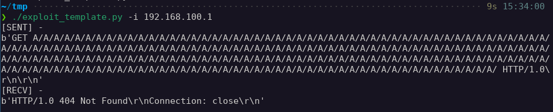

This may not look like much but it should be crashing the target. The easiest way to confirm will be to run `ps` on the target (in the emulation). **The PID of uhttpd should change**. This is because uhttpd is crashing and being restarted by the operating system of the router.

You should also see some stuff about `SIGSEGV` and some `412f412f`s in the emulation terminal as an error message.

SIGSEGV is a **segmentation fault** or a memory error. Its good news for us!

Remember when you get a crash, the first priority is to replicate it, then to triage it!

# Debugging

Debugging is like fixing a car while its running... but for code

GDB -> GNU DeBugger and is the goto debugger for Linux-ish platforms

GDBServer -> GDB...Server  
a light weight remote debugging option that supports multiple architectures.

Additionally, Linux-ish platforms can support gdb core dumps for processes when they crash.

For most targets in the wild, you will need to compile your own gdbserver and transfer it to the target, but we have included it already on the target.

**Building GDBServer**

If you need to compile it for a different target consider using buildroot, openwrt, or another tool to compile your build chain for you. Otherwise you need to setup the whole toolchain and coordinate the path for the specific libraries needed to build the target architecture on the host

## GDBServer on the Target

Use the `ps` command on the target to find the PID of the http daemon. You then can connect gdbserver to it and it will send out the debugging information so you can debug it from your host system. Plug in your HOST IP and then any port will work as long as you are consistent

```
gdbserver HOST:PORT --attach PID &
```

*the & at the end tells it to run in the background, so you can continue using the terminal*

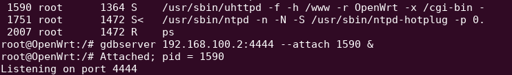

## GDB on the Host

Now to connect it to your host machine enter the following: (use the same port as you used above)

```
gdb-multiarch
gef-remote 192.168.100.1 4444
```

*if you are not using gef, "target remote" will work here instead. Target remote will also work for gef but gef-remote enables gef functions for the gdbserver*

With gef installed, you should see an output like this listing all the registers. It is much more beginner friendly than vanilla GDB

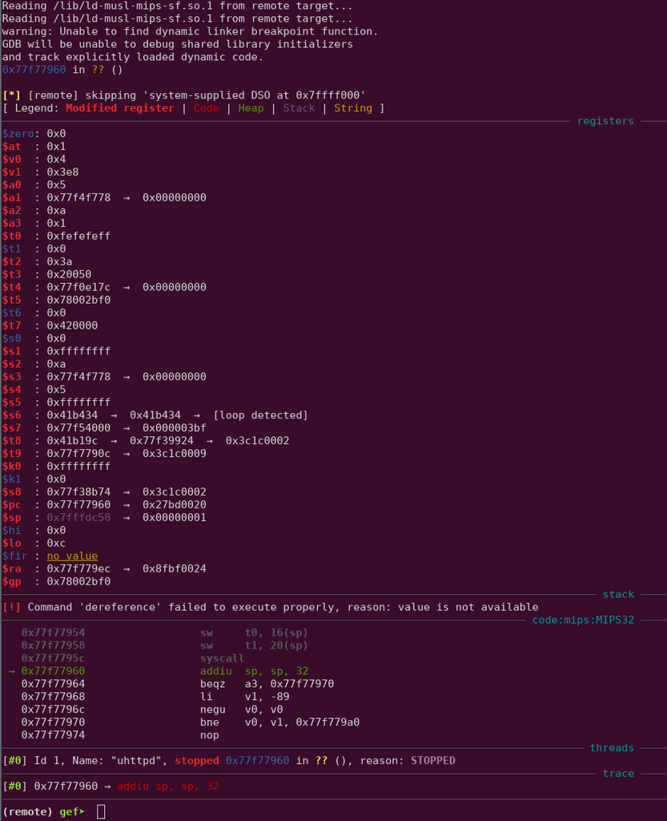

Hit `c` then enter on gef to continue the program. When the debugger attaches it halts execution. Now we can throw our packet and see whats going on.

Throw the packet like before with `./exploit_template.py -i 192.168.100.1`

## Crash from the other side

You should see something like this, this is what's happening in the program as it crashes

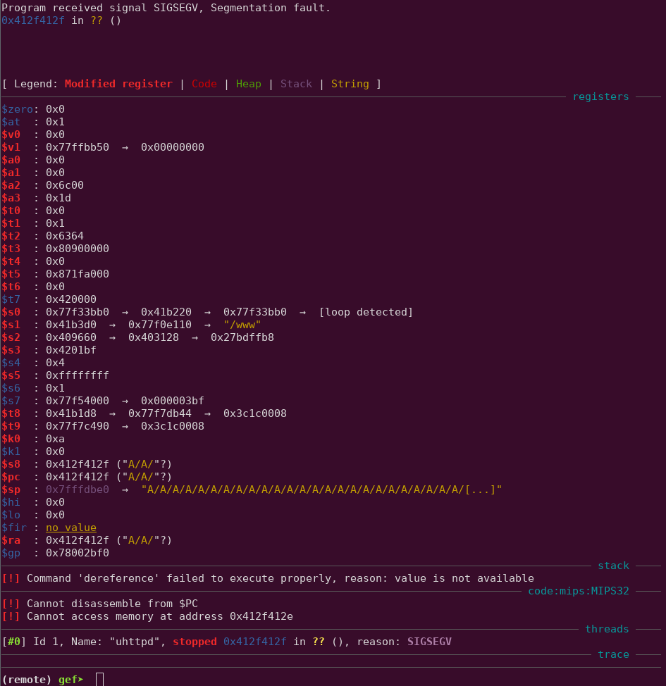

*if it doesn't try entering `c` again to continue past the SIGPIPE*

During this course you may see **SIGPIPE** as an error. This is **signal broken pipe** for the kernal and happens from a socket communication not closing properly (ie each packet when fuzzing). They are very common and handled during normal operations but because we are in a debugger it is stopping us each time.

`handle SIGPIPE nostop noprint pass` tells the debugger to ignore this, but you do not need to enter this unless the SIGPIPEs are annoying.

Where are we at? What is going on? What is a **Segmentation Fault** (SIGSEGV)?

**Think about it a minute, then click here**

Remember that memory map we looked at earlier? Check against that on your target

```
cat /proc/<pid>/maps
```

and compare the address in PC against it.

The Segmentation fault is because the program is trying to access the instruction at the address 412f412f but nothing is mapped there, which gives us this error. Is there anything else strange about it?

If you're not familiar with ascii tables consider running the following

```
man ascii
```

You may notice that the `412f412f` equals a section of the long string we sent "A/A/"

That means we can control that value and that is the value going directly in PC. **We can make it GO wherever we want**.

## Useful GDB Commands

Here are some useful commands for debugging with gdb, this is by no means an exhaustive list, google will have far more

Continue (c) - starts/resumes execution of the program until the next stop, breakpoint, or error

Display (d) / - prints the value at **every step** in the debugger

If you are not using GEF you can use `display/i $pc` or `d/i $pc` and it will print the instruction pointed to by the PC register at every stop

`x/<length> <format> <address>` to display memory contents, the length and format are optional and the address can be a hexidecimal value or a register

`x/10xw $sp-5` would print 10 (decimal) hex word groupings starting from 5 (decimal) before the stack pointer

Common format choices can be: x - hexadecimal, d - decimal, c - char, s - string, i - instruction

Here are common grouping size modifiers: b - byte, h - halfword (16 bits), w - word (32 bits), g - giant word (64 bits)

Breakpoints (b) `b *0x<address>` tells the debugger to stop when it hits an address

Info (i) `i r` displays the contents of the target, in this example it would print values in the registers

`handle SIGPIPE nostop noprint pass` to ignore SIGPIPEs

In gef the command `context` reprints that nice view at each stop

In gef, the command gef will display the avaible commands and a description of each

In gdb and gef, the command help will display the available commands from gdb